# Bichromatic operations and metric joins

by: Eric S. Téllez

**Bichromatic** (cross-dataset) operations find closest pairs between two *different* collections under a shared metric. This is distinct from standard (monochromatic) nearest-neighbor search, which looks inside a single dataset.

`SimilaritySearch.jl` provides three bichromatic functions in its `Bichromatic` submodule (re-exported at the top level):

| Function | What it computes |
| --- | --- |
| `bichromatic_closestpair` | The single globally closest pair `(a, b)` across `A × B` |
| `bichromatic_kclosestpairs` | The `k` closest pairs across `A × B` |
| `bichromatic_metricjoin` | Adaptive metric join: each `a ∈ A` gets all `b ∈ B` within a *locally adaptive* radius |

```julia
using SimilaritySearch, SimSearchManifoldLearning
using Plots, StatsBase, LinearAlgebra, Markdown, Random, Printf
```

## 2D visual example

We start with a toy 2D dataset to make the operations visually concrete.

```julia
Random.seed!(1)

# A: 40 blue "facility" points — scattered across the plane
A_mat = 8f0 .* rand(Float32, 2, 40) .- 4f0
A_db  = MatrixDatabase(A_mat)

# B: 80 red "client" points — clustered in two dense regions
B_mat = hcat(randn(Float32, 2, 50) .* 0.6f0 .+ Float32[-2, 1],
             randn(Float32, 2, 30) .* 0.4f0 .+ Float32[2, -2])
B_db  = MatrixDatabase(B_mat)

dist  = Dist.L2()
idxA  = ExhaustiveSearch(dist, A_db)
ctx   = GenericContext()
```

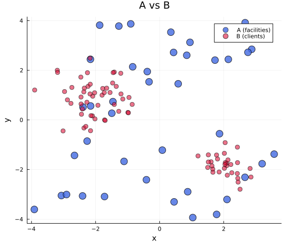

```julia
# Baseline scatter
scatter(A_mat[1, :], A_mat[2, :]; ms=8, msw=1, mc=:royalblue, ma=0.8, label="A (facilities)")
scatter!(B_mat[1, :], B_mat[2, :]; ms=5, mc=:crimson, ma=0.6, label="B (clients)")
plot!(; legend=:topright, title="A vs B", xlabel="x", ylabel="y", fmt=:png, size=(600, 520))
```

## `bichromatic_closestpair`

Finds the single pair `(aᵢ, bⱼ)` with the smallest distance across all of `A × B`.

```
Closest pair: A[26] and B[41], distance = 0.0440
```

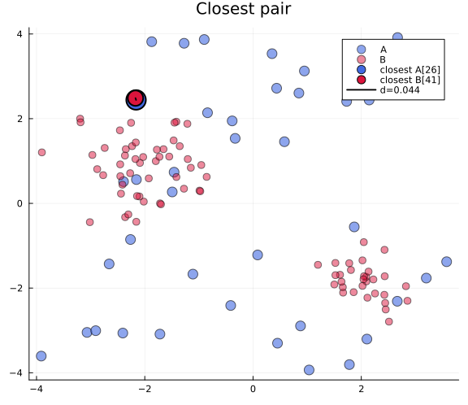

```julia
i, j, d = bichromatic_closestpair(idxA, ctx, B_db)
println("Closest pair: A[$i] and B[$j], distance = $(@sprintf "%.4f" d)")

# Draw it
scatter(A_mat[1, :], A_mat[2, :]; ms=7, mc=:royalblue, ma=0.6, label="A")
scatter!(B_mat[1, :], B_mat[2, :]; ms=5, mc=:crimson, ma=0.5, label="B")
scatter!([A_mat[1,i]], [A_mat[2,i]]; ms=14, mc=:royalblue, msw=2, label="closest A[$i]")
scatter!([B_mat[1,j]], [B_mat[2,j]]; ms=11, mc=:crimson, msw=2, label="closest B[$j]")
plot!([A_mat[1,i], B_mat[1,j]], [A_mat[2,i], B_mat[2,j]]; lw=2, lc=:black, label="d=$(round(d,digits=3))")
plot!(; legend=:topright, title="Closest pair", fmt=:png, size=(600, 520))
```

## `bichromatic_kclosestpairs`

Retrieves the `k` globally closest pairs across `A × B`.

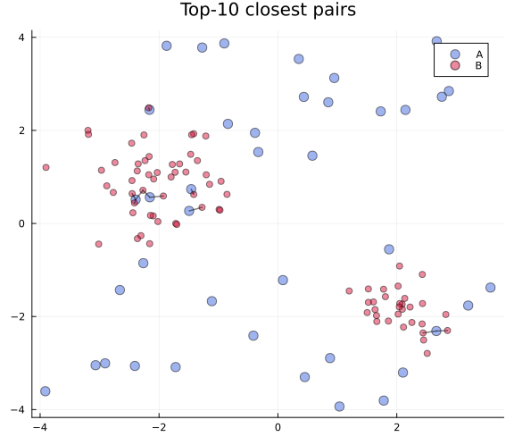

```julia
k = 10
pairs = bichromatic_kclosestpairs(idxA, ctx, B_db; k)

scatter(A_mat[1, :], A_mat[2, :]; ms=6, mc=:royalblue, ma=0.5, label="A")
scatter!(B_mat[1, :], B_mat[2, :]; ms=4, mc=:crimson, ma=0.5, label="B")
for (ai, bi, di) in pairs
    plot!([A_mat[1,ai], B_mat[1,bi]], [A_mat[2,ai], B_mat[2,bi]];
          lw=1.5, lc=:black, la=0.5, label="")
end
plot!(; legend=:topright, title="Top-$k closest pairs", fmt=:png, size=(600, 520))
```

## `bichromatic_metricjoin`

Standard joins use a fixed global radius `r`. In non-uniform datasets this produces too many matches in dense regions and none in sparse ones. `bichromatic_metricjoin` adapts the cutoff radius *per query point* from the local density of its `k` candidate neighbours.

```julia
# Use approximate bichromatic search (SearchGraph) for the join
idxA_approx, ctxA_approx = let
    G = SearchGraph(dist, A_db)
    gctx = SearchGraphContext(hyperparameters_callback=OptimizeParameters(MinRecall(0.95)))
    index!(G, gctx)
    G, gctx
end

join_pairs = bichromatic_metricjoin(idxA_approx, ctxA_approx, B_db; k=8)
println("Adaptive join produced $(length(join_pairs)) matched pairs")
```

[output not shown]

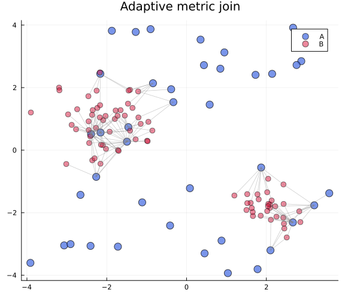

```julia
scatter(A_mat[1, :], A_mat[2, :]; ms=7, mc=:royalblue, ma=0.7, label="A")
scatter!(B_mat[1, :], B_mat[2, :]; ms=5, mc=:crimson, ma=0.5, label="B")
for (ai, bi, di) in join_pairs
    plot!([A_mat[1,ai], B_mat[1,bi]], [A_mat[2,ai], B_mat[2,bi]];
          lw=0.8, lc=:gray, la=0.4, label="")
end
plot!(; legend=:topright, title="Adaptive metric join", fmt=:png, size=(600, 520))
```

## Exact vs approximate bichromatic search

The convenience form `bichromatic_closestpair(dist, A, B; recall=r)` automatically builds an approximate `SearchGraph` when `recall < 1.0`:

```julia
# Exact
i_ex, j_ex, d_ex = bichromatic_closestpair(dist, A_db, B_db)

# Approximate (builds SearchGraph internally, targets 90% recall)
i_ap, j_ap, d_ap = bichromatic_closestpair(dist, A_db, B_db; recall=0.9)

println("Exact  : A[$i_ex] — B[$j_ex], d = $(@sprintf "%.4f" d_ex)")
println("Approx : A[$i_ap] — B[$j_ap], d = $(@sprintf "%.4f" d_ap)")
println("Same pair: $(i_ex == i_ap && j_ex == j_ap)")
```

```
LOG add! sp=1 ep=40 BeamSearch(bsize=4, Δ=1.0, maxvisits=1000000) n.size-quantiles=[0.0, 2.0, 2.0, 3.0, 4.0] mem=433MB max-rss=1338MB 2026-08-27T14:30:55.043
Exact  : A[26] — B[41], d = 0.0440
Approx : A[26] — B[41], d = 0.0440
Same pair: true
```

## Word embedding example: cross-language closest pairs

Using the Wikipedia LSI word embeddings generated for this demo site, we can find the English words closest to a set of Spanish words — a zero-shot cross-lingual alignment experiment.

> **Note**: requires `demos/data/wiki-es-lsi.txt` and `demos/data/wiki-en-lsi.txt` generated by `generate_wiki_embeddings.jl`.

```julia
# Helper to load GloVe-format embeddings
function load_glove(path; n=50_000, dtype=Float16)
    lines = readlines(path)
    n = min(n, length(lines))
    dim = length(split(lines[1])) - 1
    M   = Matrix{dtype}(undef, dim, n)
    voc = Vector{String}(undef, n)
    for i in 1:n
        parts   = split(lines[i])
        voc[i]  = parts[1]
        for (j, v) in enumerate(@view parts[2:end])
            M[j, i] = parse(Float32, v)
        end
    end
    M, voc
end

emb_es, voc_es = load_glove(joinpath(@__DIR__, "data", "wiki-es-lsi.txt"); n=80_000)
emb_en, voc_en = load_glove(joinpath(@__DIR__, "data", "wiki-en-lsi.txt"); n=80_000)
v2id_es = Dict(w => i for (i, w) in enumerate(voc_es))
v2id_en = Dict(w => i for (i, w) in enumerate(voc_en))
```

```julia
# Pick a set of Spanish words and find their closest English counterparts
# (Both embedding spaces are independent LSI spaces — alignment is approximate)
es_words = ["física", "historia", "computación", "música", "filosofía",
            "matemáticas", "biología", "química", "literatura", "medicina"]

es_ids   = [v2id_es[w] for w in es_words if haskey(v2id_es, w)]
A_words  = MatrixDatabase(Float32.(emb_es[:, es_ids]))

# Build English index
B_words  = MatrixDatabase(Float32.(emb_en))
dist_cos = Dist.NormCosine()
idx_en   = SearchGraph(dist_cos, B_words)
ctx_en   = SearchGraphContext(hyperparameters_callback=OptimizeParameters(MinRecall(0.95)))
index!(idx_en, ctx_en)
```

```julia
# For each Spanish word, find the 5 closest English words
res = knnqueue(ctx_en, 5)
L = [
    "## Spanish → English cross-lingual nearest neighbours (LSI-based)",
    "| Spanish | English neighbours |",
    "|---------|-------------------|"
]
for (es_w, eid) in zip(es_words, es_ids)
    haskey(v2id_es, es_w) || continue
    reuse!(res, 5)
    search(idx_en, ctx_en, Float32.(emb_es[:, eid]), res)
    en_nn = join(["$(voc_en[p.id]) ($(@sprintf "%.3f" p.dist))" for p in IdDistView(res)], ", ")
    push!(L, "| **$es_w** | $en_nn |")
end
Markdown.parse(join(L, "\n")) |> display
```

Spanish → English cross-lingual nearest neighbours (LSI-based)

| Spanish | English neighbours |
| --- | --- |
| **física** | Andronikashvili (0.809), anglicized (0.815), Racha (0.818), Glynn (0.821), Saoirse (0.822) |
| **historia** | Evald (0.794), Estonia (0.795), Lembit (0.797), Toivo (0.804), Kielland (0.805) |
| **computación** | coped (0.767), west (0.780), east (0.786), south (0.789), embattled (0.794) |
| **música** | Pehrsson (0.717), Houten (0.736), Guthrum (0.736), Anglian (0.739), Timorese (0.744) |
| **filosofía** | Dorough (0.775), Darien (0.785), Heckart (0.787), Kristen (0.788), Staton (0.789) |
| **matemáticas** | west (0.751), east (0.757), north (0.758), approximately (0.758), south (0.763) |
| **biología** | Episode (0.750), Shannen (0.756), Felicity (0.757), Edie (0.761), Roseanne (0.773) |
| **química** | approximately (0.763), lies (0.769), Wrocław (0.773), west (0.774), east (0.780) |
| **literatura** | countries (0.774), across (0.785), Transcaucasia (0.793), bowstring (0.805), Truss (0.807) |
| **medicina** | Makin (0.780), Amazing (0.796), Episode (0.797), Loser (0.799), Supergirl (0.800) |

## Environment and dependencies

```
Julia Version 1.12.7
Commit 6d172b025e4 (2026-08-15 08:05 UTC)
Build Info:
  Official https://julialang.org release
Platform Info:
  OS: Linux (x86_64-linux-gnu)
  CPU: 64 × Intel(R) Xeon(R) Silver 4216 CPU @ 2.10GHz
  WORD_SIZE: 64
  LLVM: libLLVM-18.1.7 (ORCJIT, cascadelake)
  GC: Built with stock GC
Threads: 64 default, 1 interactive, 64 GC (on 64 virtual cores)
Environment:
  JULIA_PROJECT = @.
  JULIA_NUM_THREADS = auto
  JULIA_LOAD_PATH = @:@stdlib
Status `~/Research/SimilaritySearchDemos/Project.toml`
  [aaaa29a8] Clustering v0.15.8
  [944b1d66] CodecZlib v0.7.9
  [a93c6f00] DataFrames v1.8.2
  [f67ccb44] HDF5 v0.17.3
  [0f8b85d8] JSON3 v1.14.3
  [23fbe1c1] Latexify v0.16.12
  [eb30cadb] MLDatasets v0.7.21
  [06eb3307] ManifoldLearning v0.9.0
⌅ [ca7969ec] PlotlyLight v0.11.1
  [91a5bcdd] Plots v1.41.7
  [27ebfcd6] Primes v0.5.7
  [92933f4c] ProgressMeter v1.11.0
  [ca7ab67e] SimSearchManifoldLearning v0.4.0 `../SimSearchManifoldLearning.jl`
  [053f045d] SimilaritySearch v1.2.0 `../SimilaritySearch.jl`
⌅ [2913bbd2] StatsBase v0.33.21
  [f3b207a7] StatsPlots v0.15.8
  [7f6f6c8a] TextSearch v1.1.1 `../TextSearch.jl`
Info Packages marked with ⌅ have new versions available but compatibility constraints restrict them from upgrading. To see why use `status --outdated`
```